# HealthBalance: Precision Disease Detection with ML

## Nilkumar Patel: 8983991

## Raj Patel : 8982178

## Section - 1

## Group - 13

```python
import pandas as pd  # For data manipulation and analysis
import numpy as np  # For numerical computations
from sklearn.model_selection import train_test_split, GridSearchCV  # For data splitting and hyperparameter tuning
from sklearn.metrics import classification_report, confusion_matrix, roc_curve, auc  # For evaluating model performance
import matplotlib.pyplot as plt  # For creating static visualizations
import seaborn as sns  # For statistical data visualization
import plotly.express as px  # For interactive data visualizations
import plotly.graph_objects as go  # For creating advanced interactive visualizations

# The above libraries are commonly used for data science workflows, including data preprocessing, visualization,
# machine learning model training, and performance evaluation.
```

```python
# Loading the data
train_data = pd.read_csv("C:/Users/imraj/Desktop/archive (1)/Training.csv")
test_data = pd.read_csv("C:/Users/imraj/Desktop/archive (1)/Testing.csv")
```

## EDA

### Dataset Overview

```python
# Check the shape of the dataset
print("Training data shape:", train_data.shape)

# Display column names
print("\nColumns in the dataset:\n", train_data.columns.tolist())

# Summary of the dataset
print("\nData Summary:\n", train_data.info())

# Check for missing values
print("\nMissing values in each column:\n", train_data.isnull().sum())
```

```
Training data shape: (4920, 134)

Columns in the dataset:
 ['itching', 'skin_rash', 'nodal_skin_eruptions', 'continuous_sneezing', 'shivering', 'chills', 'joint_pain', 'stomach_pain', 'acidity', 'ulcers_on_tongue', 'muscle_wasting', 'vomiting', 'burning_micturition', 'spotting_ urination', 'fatigue', 'weight_gain', 'anxiety', 'cold_hands_and_feets', 'mood_…
<class 'pandas.core.frame.DataFrame'>
RangeIndex: 4920 entries, 0 to 4919
Columns: 134 entries, itching to Unnamed: 133
dtypes: float64(1), int64(132), object(1)
memory usage: 5.0+ MB

Data Summary:
 None

Missing values in each column:
 itching                    0
skin_rash                  0
nodal_skin_eruptions       0
continuous_sneezing        0
shivering                  0
                        ...
blister                    0
red_sore_around_nose       0
yellow_crust_ooze          0
prognosis                  0
Unnamed: 133            4920
Length: 134, dtype: int64
```

## Statistical Overview

```python
# Descriptive statistics for numerical columns
print("\nStatistical Summary:\n", train_data.describe())

# Checking value counts for a specific categorical column
print("\nValue counts for a column:\n", train_data['skin_rash'].value_counts())
```

```
Statistical Summary:
            itching    skin_rash  nodal_skin_eruptions  continuous_sneezing  \
count  4920.000000  4920.000000           4920.000000          4920.000000
mean      0.137805     0.159756              0.021951             0.045122
std       0.344730     0.366417              0.146539             0.207593
min       0.000000     0.000000              0.000000             0.000000
25%       0.000000     0.000000              0.000000             0.000000
50%       0.000000     0.000000              0.000000             0.000000
75%       0.000000     0.000000              0.000000             0.000000
max       1.000000     1.000000              1.000000             1.000000

         shivering       chills   joint_pain  stomach_pain      acidity  \
count  4920.000000  4920.000000  4920.000000   4920.000000  4920.000000
mean      0.021951     0.162195     0.139024      0.045122     0.045122
std       0.146539     0.368667     0.346007      0.207593     0.207593
min       0.000000     0.000000     0.000000      0.000000     0.000000
25%       0.000000     0.000000     0.000000      0.000000     0.000000
50%       0.000000     0.000000     0.000000      0.000000     0.000000
75%       0.000000     0.000000     0.000000      0.000000     0.000000
max       1.000000     1.000000     1.000000      1.000000     1.000000

       ulcers_on_tongue  ...   blackheads     scurring  skin_peeling  \
count       4920.000000  ...  4920.000000  4920.000000   4920.000000
mean           0.021951  ...     0.021951     0.021951      0.023171
std            0.146539  ...     0.146539     0.146539      0.150461
min            0.000000  ...     0.000000     0.000000      0.000000
25%            0.000000  ...     0.000000     0.000000      0.000000
50%            0.000000  ...     0.000000     0.000000      0.000000
75%            0.000000  ...     0.000000     0.000000      0.000000
max            1.000000  ...     1.000000     1.000000      1.000000

       silver_like_dusting  small_dents_in_nails  inflammatory_nails  \
count          4920.000000           4920.000000         4920.000000
mean              0.023171              0.023171            0.023171
std               0.150461              0.150461            0.150461
min               0.000000              0.000000            0.000000
25%               0.000000              0.000000            0.000000
50%               0.000000              0.000000            0.000000
75%               0.000000              0.000000            0.000000
max               1.000000              1.000000            1.000000

           blister  red_sore_around_nose  yellow_crust_ooze  Unnamed: 133
count  4920.000000           4920.000000        4920.000000           0.0
mean      0.023171              0.023171           0.023171           NaN
std       0.150461              0.150461           0.150461           NaN
min       0.000000              0.000000           0.000000           NaN
25%       0.000000              0.000000           0.000000           NaN
50%       0.000000              0.000000           0.000000           NaN
75%       0.000000              0.000000           0.000000           NaN
max       1.000000              1.000000           1.000000           NaN

[8 rows x 133 columns]

Value counts for a column:
 skin_rash
0    4134
1     786
Name: count, dtype: int64
```

```python
# Printing a message to indicate the start of the training data overview
print("Training Data Overview:")

# Displaying the first few rows of the training dataset (default is 5 rows)
# This helps us get a quick look at the structure and content of the data
print(train_data.head())
```

```
Training Data Overview:
   itching  skin_rash  nodal_skin_eruptions  continuous_sneezing  shivering  \
0        1          1                     1                    0          0
1        0          1                     1                    0          0
2        1          0                     1                    0          0
3        1          1                     0                    0          0
4        1          1                     1                    0          0

   chills  joint_pain  stomach_pain  acidity  ulcers_on_tongue  ...  scurring  \
0       0           0             0        0                 0  ...         0
1       0           0             0        0                 0  ...         0
2       0           0             0        0                 0  ...         0
3       0           0             0        0                 0  ...         0
4       0           0             0        0                 0  ...         0

```

[output cut: 22 more lines]

```python
# Printing a message to indicate the start of data information section
print("\nData Information:")

# Displaying information about the dataset like column types, non-null values, etc.
# This helps us understand the structure and completeness of the data
print(train_data.info())

# Printing a message to indicate the start of class distribution section
print("\nClass Distribution:")

# Displaying the distribution of the 'prognosis' column to see how many instances of each class are present
# This helps in understanding the balance of classes in the dataset
print(train_data['prognosis'].value_counts())
```

```
Data Information:
<class 'pandas.core.frame.DataFrame'>
RangeIndex: 4920 entries, 0 to 4919
Columns: 134 entries, itching to Unnamed: 133
dtypes: float64(1), int64(132), object(1)
memory usage: 5.0+ MB
None

Class Distribution:
prognosis
Fungal infection                           120
Allergy                                    120
GERD                                       120
Chronic cholestasis                        120
Drug Reaction                              120
Peptic ulcer diseae                        120
AIDS                                       120
Diabetes                                   120
Gastroenteritis                            120
Bronchial Asthma                           120
Hypertension                               120
Migraine                                   120
Cervical spondylosis                       120
Paralysis (brain hemorrhage)               120
Jaundice                                   120
Malaria                                    120
Chicken pox                                120
Dengue                                     120
Typhoid                                    120
hepatitis A                                120
Hepatitis B                                120
Hepatitis C                                120
Hepatitis D                                120
Hepatitis E                                120
Alcoholic hepatitis                        120
Tuberculosis                               120
Common Cold                                120
Pneumonia                                  120
Dimorphic hemmorhoids(piles)               120
Heart attack                               120
Varicose veins                             120
Hypothyroidism                             120
Hyperthyroidism                            120
Hypoglycemia                               120
Osteoarthristis                            120
Arthritis                                  120
(vertigo) Paroymsal  Positional Vertigo    120
Acne                                       120
Urinary tract infection                    120
Psoriasis                                  120
Impetigo                                   120
Name: count, dtype: int64
```

## Null Values Check

```python
# Checking for null values in training data
train_nulls = train_data.isnull().sum()
test_nulls = test_data.isnull().sum()

# Printing columns with null values in training data
if train_nulls.any():
    print("Columns with null values in Training Data:")
    print(train_nulls[train_nulls > 0])
else:
    print("No null values in Training Data.")

# Printing columns with null values in test data
if test_nulls.any():
    print("\nColumns with null values in Test Data:")
    print(test_nulls[test_nulls > 0])
else:
    print("No null values in Test Data.")
```

```
Columns with null values in Training Data:
Unnamed: 133    4920
dtype: int64
No null values in Test Data.
```

## Inspecting Columns before dropping

```python
# Inspecting the column before dropping
print("\nInspecting 'Unnamed: 133' column:")
print(train_data['Unnamed: 133'].head())
```

```
Inspecting 'Unnamed: 133' column:
0   NaN
1   NaN
2   NaN
3   NaN
4   NaN
Name: Unnamed: 133, dtype: float64
```

## Checking Column Names

```python
# Checking column names
print("\nColumn names in Training Data:")
print(train_data.columns)
```

```
Column names in Training Data:
Index(['itching', 'skin_rash', 'nodal_skin_eruptions', 'continuous_sneezing',
       'shivering', 'chills', 'joint_pain', 'stomach_pain', 'acidity',
       'ulcers_on_tongue',
       ...
       'scurring', 'skin_peeling', 'silver_like_dusting',
       'small_dents_in_nails', 'inflammatory_nails', 'blister',
       'red_sore_around_nose', 'yellow_crust_ooze', 'prognosis',
       'Unnamed: 133'],
      dtype='object', length=134)
```

## Dropping Column with Null Values in Training Data

```python
# Dropping the column with null values in the training data
train_data = train_data.drop(columns=['Unnamed: 133'])

# Verifying that the column is removed
print("\nColumns in Training Data after dropping 'Unnamed: 133':")
print(train_data.columns)
```

```
Columns in Training Data after dropping 'Unnamed: 133':
Index(['itching', 'skin_rash', 'nodal_skin_eruptions', 'continuous_sneezing',
       'shivering', 'chills', 'joint_pain', 'stomach_pain', 'acidity',
       'ulcers_on_tongue',
       ...
       'blackheads', 'scurring', 'skin_peeling', 'silver_like_dusting',
       'small_dents_in_nails', 'inflammatory_nails', 'blister',
       'red_sore_around_nose', 'yellow_crust_ooze', 'prognosis'],
      dtype='object', length=133)
```

## Verifying Column is Removed

```python
# Verifying that the column is removed
print("\nColumns in Test Data:")
print(test_data.columns)
```

```
Columns in Test Data:
Index(['itching', 'skin_rash', 'nodal_skin_eruptions', 'continuous_sneezing',
       'shivering', 'chills', 'joint_pain', 'stomach_pain', 'acidity',
       'ulcers_on_tongue',
       ...
       'blackheads', 'scurring', 'skin_peeling', 'silver_like_dusting',
       'small_dents_in_nails', 'inflammatory_nails', 'blister',
       'red_sore_around_nose', 'yellow_crust_ooze', 'prognosis'],
      dtype='object', length=133)
```

```python
import pandas as pd

def find_duplicate_columns(df):
    """Find duplicate columns in a DataFrame."""
    duplicate_columns = df.columns[df.columns.duplicated()].tolist()
    column_counts = df.columns.value_counts()
    duplicates = column_counts[column_counts > 1]

    return duplicates

# Finding duplicate columns
train_duplicates = find_duplicate_columns(train_data)
test_duplicates = find_duplicate_columns(test_data)

# Printing results
print("Duplicate columns in training data:")
print(train_duplicates)

print("\nDuplicate columns in testing data:")
print(test_duplicates)
```

```
Duplicate columns in training data:
Series([], Name: count, dtype: int64)

Duplicate columns in testing data:
Series([], Name: count, dtype: int64)
```

## Class Distribution in Training Data

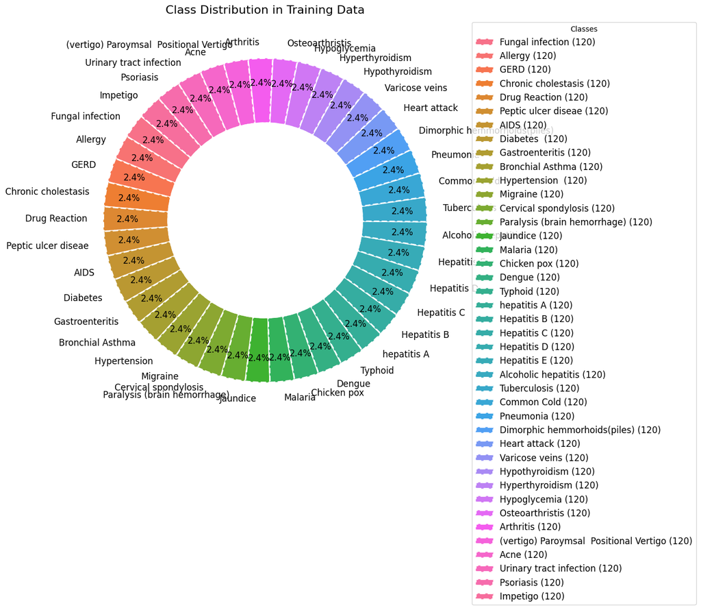

```python
import matplotlib.pyplot as plt
import seaborn as sns

# Computing class distribution
class_counts = train_data['prognosis'].value_counts()
class_labels = class_counts.index
class_sizes = class_counts.values

# Defining a more vibrant color palette
colors = sns.color_palette('husl', len(class_labels))

# Creating Donut Chart with enhancements
plt.figure(figsize=(14, 10))
wedges, texts, autotexts = plt.pie(class_sizes,
                                   labels=class_labels,
                                   autopct='%1.1f%%',
                                   colors=colors,
                                   startangle=140,
                                   wedgeprops=dict(width=0.4, edgecolor='w', linestyle='--', linewidth=2),
                                   textprops={'fontsize': 12, 'color': 'black'},
                                   pctdistance=0.85)  # Distance of labels from the center

# Adding a circle at the center to make it look like a donut chart
centre_circle = plt.Circle((0,0),0.6,fc='white', edgecolor='w', linewidth=2)
fig = plt.gcf()
fig.gca().add_artist(centre_circle)

# Enhancing text for better visibility
for autotext in autotexts:
    autotext.set_fontsize(12)
    autotext.set_color('black')

# Adding custom labels to wedges
for i, wedge in enumerate(wedges):
    label = class_labels[i]
    size = class_sizes[i]
    wedge.set_label(f'{label} ({size})')

# Adding a title with a larger font size
plt.title('Class Distribution in Training Data', fontsize=16)

# Displaying the legend with a more descriptive format
plt.legend(loc='upper left', bbox_to_anchor=(1, 1), title='Classes', fontsize=12)

# Showing the plot
plt.show()
```

## Feature Correlation Matrix

```
### Feature Correlation
```

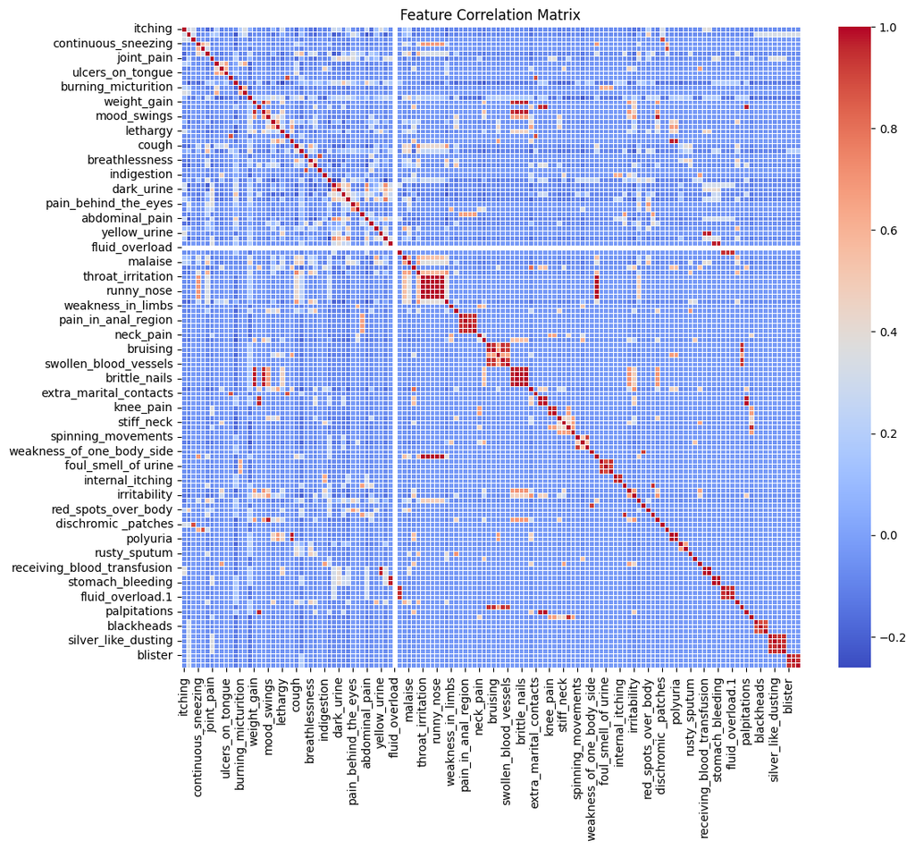

```python
# Featuring Correlation
print("### Feature Correlation")
plt.figure(figsize=(12, 10))
correlation_matrix = train_data.drop('prognosis', axis=1).corr()
sns.heatmap(correlation_matrix, annot=False, cmap='coolwarm', fmt='.2f', linewidths=0.5)
plt.title('Feature Correlation Matrix')
plt.show()
```

## Classification Report

```python
from sklearn.ensemble import RandomForestClassifier
from sklearn.metrics import classification_report, confusion_matrix, accuracy_score

# Preprocessing
X = train_data.drop('prognosis', axis=1)
y = train_data['prognosis']

# Converting categorical target variable to numeric
y = pd.factorize(y)[0]  # Encode categorical target

# Splitting the data into training and validation sets
X_train, X_val, y_train, y_val = train_test_split(X, y, test_size=0.2, random_state=42)

# Defining and train the Random Forest model
model = RandomForestClassifier(random_state=42)
model.fit(X_train, y_train)

#Hyperparameter Tuning
params = {
    'n_estimators': [100, 200],
    'max_depth': [None, 10],
}
grid_search = GridSearchCV(model, params, cv=3, scoring='accuracy', verbose=1)
grid_search.fit(X_train, y_train)

# Best model from grid search
best_model = grid_search.best_estimator_

# Evaluating the model on the validation set
y_pred = best_model.predict(X_val)
print("\nClassification Report:")
print(classification_report(y_val, y_pred))


# Calculating accuracy on validation set
val_accuracy = accuracy_score(y_val, y_pred)
print(f"\nValidation Accuracy: {val_accuracy:.2f}")
```

```
Fitting 3 folds for each of 4 candidates, totalling 12 fits

Classification Report:
              precision    recall  f1-score   support

           0       1.00      1.00      1.00        19
           1       1.00      1.00      1.00        24
           2       1.00      1.00      1.00        28
           3       1.00      1.00      1.00        15
           4       1.00      1.00      1.00        24
           5       1.00      1.00      1.00        17
           6       1.00      1.00      1.00        30
           7       1.00      1.00      1.00        21
           8       1.00      1.00      1.00        25
           9       1.00      1.00      1.00        33
```

[output cut: 38 more lines]

## Confusion Matrix

```python
print("\nConfusion Matrix:")
conf_matrix = confusion_matrix(y_val, y_pred)
print(conf_matrix)
```

```
Confusion Matrix:
[[19  0  0 ...  0  0  0]
 [ 0 24  0 ...  0  0  0]
 [ 0  0 28 ...  0  0  0]
 ...
 [ 0  0  0 ... 26  0  0]
 [ 0  0  0 ...  0 22  0]
 [ 0  0  0 ...  0  0 24]]
```

## Confusion matrix Visualization

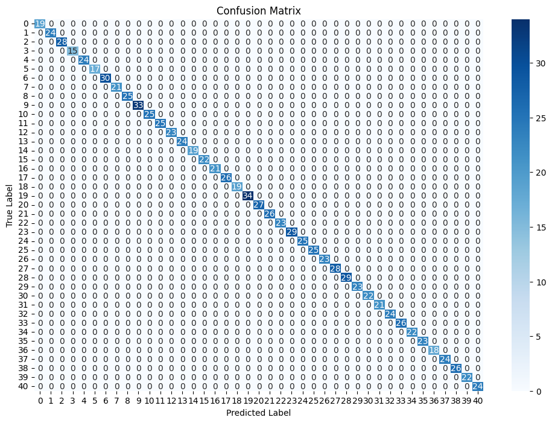

```python
# Confusion Matrix Visualization
plt.figure(figsize=(12, 8))
sns.heatmap(conf_matrix, annot=True, fmt='d', cmap='Blues', xticklabels=best_model.classes_, yticklabels=best_model.classes_)
plt.title('Confusion Matrix')
plt.xlabel('Predicted Label')
plt.ylabel('True Label')
plt.show()
```

```python
# Test Set Evaluation
X_test = test_data.drop('prognosis', axis=1)
y_test = test_data['prognosis']
```

## Test set Classification

```python
# Converting categorical target variable to numeric for test set
y_test_encoded = pd.factorize(y_test)[0]  # Encode categorical target

# Aligning columns in test set with training set
X_test = X_test.reindex(columns=X.columns, fill_value=0)

# Predicting on test set
y_test_pred = best_model.predict(X_test)

# Classification Report for Test Set
print("\nTest Set Classification Report:")
print(classification_report(y_test_encoded, y_test_pred))

# Calculating the accuracy on test set
test_accuracy = accuracy_score(y_test_encoded, y_test_pred)
print(f"\nTest Accuracy: {test_accuracy:.2f}")
```

```
Test Set Classification Report:
              precision    recall  f1-score   support

           0       1.00      0.50      0.67         2
           1       1.00      1.00      1.00         1
           2       1.00      1.00      1.00         1
           3       1.00      1.00      1.00         1
           4       1.00      1.00      1.00         1
           5       1.00      1.00      1.00         1
           6       1.00      1.00      1.00         1
           7       1.00      1.00      1.00         1
           8       1.00      1.00      1.00         1
           9       1.00      1.00      1.00         1
          10       1.00      1.00      1.00         1
          11       1.00      1.00      1.00         1
```

[output cut: 36 more lines]

## Feature Ranking

```python
# Featuring Importance using Gini Index
importances = best_model.feature_importances_
indices = np.argsort(importances)[::-1]  # Sort feature importances in descending order

# Printing the feature ranking
print("\nFeature Ranking:")
for i in range(X.shape[1]):
    print(f"{i + 1}. feature {X.columns[indices[i]]} ({importances[indices[i]]:.4f})")
```

```
Feature Ranking:
1. feature muscle_pain (0.0199)
2. feature high_fever (0.0169)
3. feature fatigue (0.0164)
4. feature itching (0.0158)
5. feature joint_pain (0.0149)
6. feature chest_pain (0.0147)
7. feature dark_urine (0.0147)
8. feature nausea (0.0147)
9. feature abdominal_pain (0.0146)
10. feature altered_sensorium (0.0136)
11. feature unsteadiness (0.0135)
12. feature lack_of_concentration (0.0134)
13. feature diarrhoea (0.0134)
14. feature internal_itching (0.0133)
15. feature vomiting (0.0133)
16. feature mild_fever (0.0130)
17. feature weight_loss (0.0127)
18. feature family_history (0.0124)
19. feature sweating (0.0121)
20. feature yellowing_of_eyes (0.0120)
21. feature movement_stiffness (0.0116)
22. feature dischromic _patches (0.0114)
23. feature red_spots_over_body (0.0112)
24. feature blister (0.0109)
25. feature neck_pain (0.0108)
26. feature stomach_pain (0.0108)
27. feature nodal_skin_eruptions (0.0107)
28. feature loss_of_appetite (0.0105)
29. feature back_pain (0.0104)
30. feature coma (0.0103)
31. feature malaise (0.0103)
32. feature abnormal_menstruation (0.0099)
33. feature headache (0.0099)
34. feature chills (0.0095)
35. feature sunken_eyes (0.0095)
36. feature passage_of_gases (0.0092)
37. feature belly_pain (0.0092)
38. feature prominent_veins_on_calf (0.0091)
39. feature shivering (0.0090)
```

[output cut: 78 more lines]

```
118. feature obesity (0.0033)
119. feature cold_hands_and_feets (0.0032)
120. feature distention_of_abdomen (0.0032)
121. feature redness_of_eyes (0.0030)
122. feature loss_of_smell (0.0028)
123. feature drying_and_tingling_lips (0.0026)
124. feature runny_nose (0.0026)
125. feature cramps (0.0024)
126. feature swollen_blood_vessels (0.0022)
127. feature anxiety (0.0019)
128. feature yellow_urine (0.0018)
129. feature mood_swings (0.0017)
130. feature weight_gain (0.0012)
131. feature puffy_face_and_eyes (0.0005)
132. feature fluid_overload (0.0000)
```

## Top 10 Feature Importances

```python
import pandas as pd
import numpy as np
import plotly.express as px

# Number of top features to display
top_n = 10

# Sorting features by importance and get the top N features
indices = np.argsort(importances)[::-1]
top_indices = indices[:top_n]
top_features = X.columns[top_indices]
top_importances = importances[top_indices]

# Creating a DataFrame for Plotly
feature_importance_df = pd.DataFrame({
    'Feature': top_features,
    'Importance': top_importances
})

# Sorting DataFrame by importance
feature_importance_df = feature_importance_df.sort_values(by='Importance', ascending=True)

# Creating an interactive bar chart with Plotly
fig = px.bar(
    feature_importance_df,
    x='Importance',
    y='Feature',
    title=f'Top {top_n} Feature Importances (Gini Index)',
    labels={'Importance': 'Importance', 'Feature': 'Feature'},
    color='Importance',
    color_continuous_scale='Viridis',
    text='Importance'
)

# Customizing layout
fig.update_layout(
    xaxis_title='Importance',
    yaxis_title='Feature',
    xaxis=dict(showgrid=True, gridcolor='LightGray'),
    yaxis=dict(showgrid=True, gridcolor='LightGray'),
    title_font_size=20,
    font_size=14,
    plot_bgcolor='white'
)

# Show plot
fig.show()
```

[output not shown]

## Logistic Regression

```python
from sklearn.linear_model import LogisticRegression
from sklearn.tree import DecisionTreeClassifier
# Define models with hyperparameter tuning
logistic = LogisticRegression(max_iter=1000)
decision_tree = DecisionTreeClassifier()

# Defining the parameter grids for both models
param_grid_logistic = {'C': [0.1, 1, 10, 100]}
param_grid_dt = {'max_depth': [None, 10, 20, 30], 'min_samples_split': [2, 5, 10]}

# Performing GridSearchCV for Logistic Regression
grid_search_logistic = GridSearchCV(logistic, param_grid_logistic, cv=3, scoring='accuracy', verbose=1)
grid_search_logistic.fit(X_train, y_train)
best_logistic = grid_search_logistic.best_estimator_

# Performing GridSearchCV for Decision Tree
grid_search_dt = GridSearchCV(decision_tree, param_grid_dt, cv=3, scoring='accuracy', verbose=1)
grid_search_dt.fit(X_train, y_train)
best_dt = grid_search_dt.best_estimator_

# Evaluating Logistic Regression model
y_pred_logistic = best_logistic.predict(X_val)
print("\nLogistic Regression Classification Report:")
print(classification_report(y_val, y_pred_logistic))

val_accuracy_logistic = accuracy_score(y_val, y_pred_logistic)
print(f"\nLogistic Regression Validation Accuracy: {val_accuracy_logistic:.2f}")
```

```
Fitting 3 folds for each of 4 candidates, totalling 12 fits
Fitting 3 folds for each of 12 candidates, totalling 36 fits

Logistic Regression Classification Report:
              precision    recall  f1-score   support

           0       1.00      1.00      1.00        19
           1       1.00      1.00      1.00        24
           2       1.00      1.00      1.00        28
           3       1.00      1.00      1.00        15
           4       1.00      1.00      1.00        24
           5       1.00      1.00      1.00        17
           6       1.00      1.00      1.00        30
           7       1.00      1.00      1.00        21
           8       1.00      1.00      1.00        25
```

[output cut: 39 more lines]

## Decision Tree

```python
# Evaluating Decision Tree model
y_pred_dt = best_dt.predict(X_val)
print("\nDecision Tree Classification Report:")
print(classification_report(y_val, y_pred_dt))

val_accuracy_dt = accuracy_score(y_val, y_pred_dt)
print(f"\nDecision Tree Validation Accuracy: {val_accuracy_dt:.2f}")
```

```
Decision Tree Classification Report:
              precision    recall  f1-score   support

           0       1.00      1.00      1.00        19
           1       1.00      1.00      1.00        24
           2       1.00      1.00      1.00        28
           3       1.00      1.00      1.00        15
           4       1.00      1.00      1.00        24
           5       1.00      1.00      1.00        17
           6       1.00      1.00      1.00        30
           7       1.00      1.00      1.00        21
           8       1.00      1.00      1.00        25
           9       1.00      1.00      1.00        33
          10       1.00      1.00      1.00        25
          11       1.00      1.00      1.00        25
```

[output cut: 36 more lines]

## Logistic Regression, Decision Tree Confusion Matrix

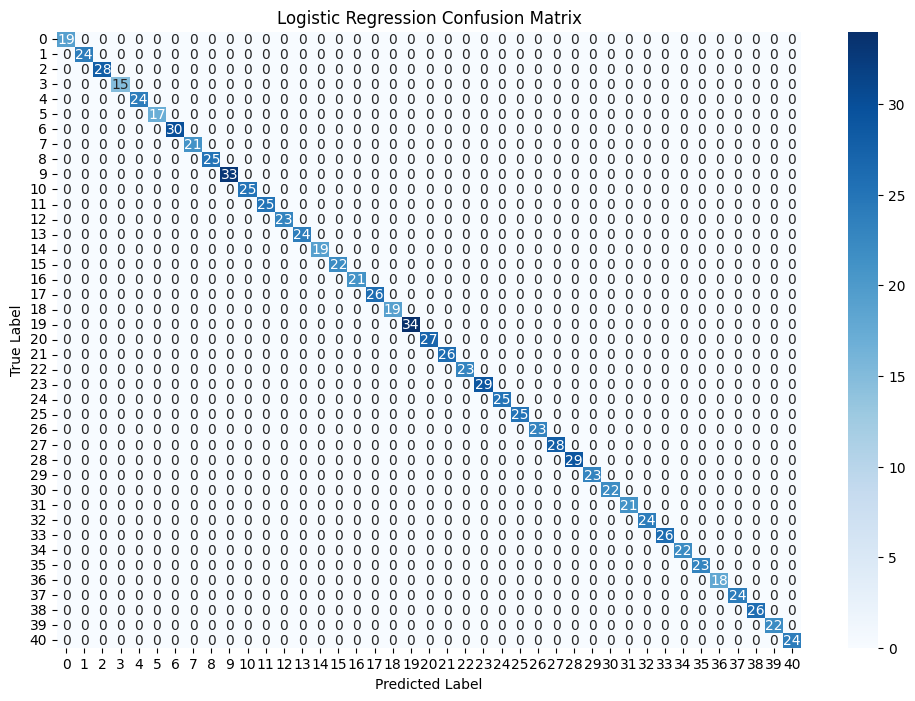

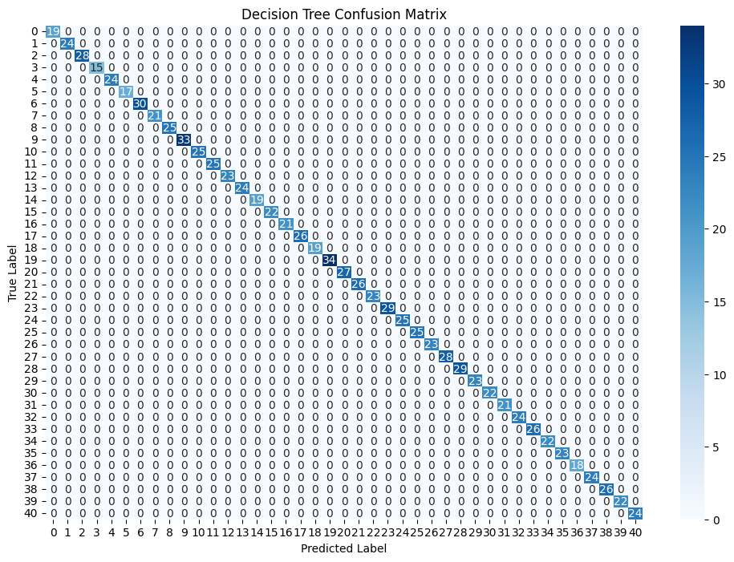

```python
# Computing confusion matrices
conf_matrix_logistic = confusion_matrix(y_val, y_pred_logistic)
conf_matrix_dt = confusion_matrix(y_val, y_pred_dt)

# Confusion Matrix Visualization for Logistic Regression
plt.figure(figsize=(12, 8))
sns.heatmap(conf_matrix_logistic, annot=True, fmt='d', cmap='Blues', xticklabels=np.unique(y), yticklabels=np.unique(y))
plt.title('Logistic Regression Confusion Matrix')
plt.xlabel('Predicted Label')
plt.ylabel('True Label')
plt.show()

# Confusion Matrix Visualization for Decision Tree
plt.figure(figsize=(12, 8))
sns.heatmap(conf_matrix_dt, annot=True, fmt='d', cmap='Blues', xticklabels=np.unique(y), yticklabels=np.unique(y))
plt.title('Decision Tree Confusion Matrix')
plt.xlabel('Predicted Label')
plt.ylabel('True Label')
plt.show()
```

## Test Set Evaluation

```python
# Test Set Evaluation
X_test = test_data.drop('prognosis', axis=1)
y_test = test_data['prognosis']

# Converting categorical target variable to numeric for test set
y_test = pd.factorize(y_test)[0]

# Evaluating Logistic Regression model on test set
y_test_pred_logistic = best_logistic.predict(X_test)
print("\nLogistic Regression Test Set Classification Report:")
print(classification_report(y_test, y_test_pred_logistic))
```

```
Logistic Regression Test Set Classification Report:
              precision    recall  f1-score   support

           0       1.00      1.00      1.00         2
           1       1.00      1.00      1.00         1
           2       1.00      1.00      1.00         1
           3       1.00      1.00      1.00         1
           4       1.00      1.00      1.00         1
           5       1.00      1.00      1.00         1
           6       1.00      1.00      1.00         1
           7       1.00      1.00      1.00         1
           8       1.00      1.00      1.00         1
           9       1.00      1.00      1.00         1
          10       1.00      1.00      1.00         1
          11       1.00      1.00      1.00         1
```

[output cut: 33 more lines]

```python
from sklearn.metrics import classification_report, accuracy_score

# Evaluating Decision Tree model on test set
y_test_pred_dt = best_dt.predict(X_test)
test_accuracy_dt = accuracy_score(y_test, y_test_pred_dt) * 100  # Convert to percentage

print("\nDecision Tree Test Set Classification Report:")
print(classification_report(y_test, y_test_pred_dt))
print(f"\nDecision Tree Test Set Accuracy: {test_accuracy_dt:.3f}%")
```

```
Decision Tree Test Set Classification Report:
              precision    recall  f1-score   support

           0       1.00      0.50      0.67         2
           1       1.00      1.00      1.00         1
           2       1.00      1.00      1.00         1
           3       1.00      1.00      1.00         1
           4       1.00      1.00      1.00         1
           5       1.00      1.00      1.00         1
           6       1.00      1.00      1.00         1
           7       1.00      1.00      1.00         1
           8       1.00      1.00      1.00         1
           9       1.00      1.00      1.00         1
          10       1.00      1.00      1.00         1
          11       1.00      1.00      1.00         1
```

[output cut: 36 more lines]

```
Logistic Regression Classification Report on Test Data:
              precision    recall  f1-score   support

           0       1.00      1.00      1.00         2
           1       1.00      1.00      1.00         1
           2       1.00      1.00      1.00         1
           3       1.00      1.00      1.00         1
           4       1.00      1.00      1.00         1
           5       1.00      1.00      1.00         1
           6       1.00      1.00      1.00         1
           7       1.00      1.00      1.00         1
           8       1.00      1.00      1.00         1
           9       1.00      1.00      1.00         1
          10       1.00      1.00      1.00         1
          11       1.00      1.00      1.00         1
```

[output cut: 140 more lines]

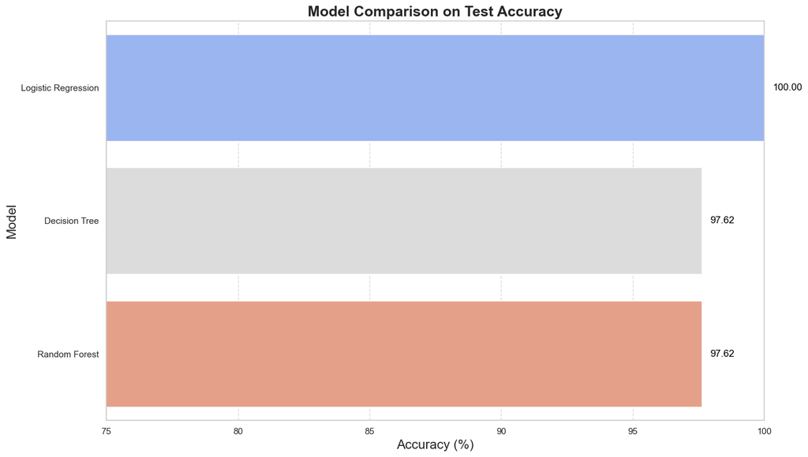

```python
# Defining models
models = {
    "Logistic Regression": LogisticRegression(max_iter=1000),
    "Decision Tree": DecisionTreeClassifier(),
    "Random Forest": RandomForestClassifier()
}

# Initializing dictionaries to store results
test_results = {}

# Training and evaluate each model on the test data
for name, model in models.items():
    model.fit(X_train, y_train)

    # Preparing test data
    X_test = test_data.drop('prognosis', axis=1)
    y_test = test_data['prognosis']
    y_test = pd.factorize(y_test)[0]

    # Predicting and evaluate
    y_test_pred = model.predict(X_test)
    accuracy = accuracy_score(y_test, y_test_pred) * 100  # Convert to percentage
    test_results[name] = accuracy

    print(f"\n{name} Classification Report on Test Data:")
    print(classification_report(y_test, y_test_pred))
    print(f"\n{name} Test Set Accuracy: {accuracy:.2f}%")

# Visualization
plt.figure(figsize=(14, 8))
sns.set(style="whitegrid")

# Creating a horizontal bar plot
ax = sns.barplot(x=list(test_results.values()), y=list(test_results.keys()), palette="coolwarm")

# Adding labels
for container in ax.containers:
    ax.bar_label(container, fmt='%.2f', padding=10, fontsize=12, color='black')

# Customizing the plot
plt.title('Model Comparison on Test Accuracy', fontsize=18, weight='bold')
plt.xlabel('Accuracy (%)', fontsize=16)
plt.ylabel('Model', fontsize=16)
plt.xlim(75, 100)  # Set x-axis range from 75 to 100
plt.grid(axis='x', linestyle='--', alpha=0.7)

plt.tight_layout()
plt.show()
```

# References

1. **Pandas**: [Documentation](https://pandas.pydata.org/pandas-docs/stable/)  
   Used for data manipulation and analysis, including loading datasets and handling missing values.
2. **NumPy**: [Documentation](https://numpy.org/doc/stable/)  
   Used for numerical computing, including array operations and handling data structures.
3. **Scikit-learn**: [Documentation](https://scikit-learn.org/stable/)  
   Used for machine learning, including model training (Random Forest, Logistic Regression, Decision Tree), splitting datasets, hyperparameter tuning (GridSearchCV), and evaluating models (classification report, confusion matrix).
4. **Matplotlib**: [Documentation](https://matplotlib.org/stable/contents.html)  
   Used for data visualization, including plotting confusion matrices and feature importance.
5. **Seaborn**: [Documentation](https://seaborn.pydata.org/)  
   Used for data visualization, including creating the donut chart for class distribution and correlation matrix heatmap.
6. **Plotly**: [Documentation](https://plotly.com/)  
   Used for creating interactive plots, including the feature importance bar chart.
7. **Kaggle**: [Website](https://www.kaggle.com/)  
   Dataset for this project sourced from Kaggle.
8. **Feature Importance (Gini Index) and Random Forest**:
   - Feature importance in Random Forest is based on the Gini index.  
     *Source*: Breiman, L. (2001). Random forests. *Machine Learning, 45*(1), 5-32.
9. **GridSearchCV**: [Documentation](https://scikit-learn.org/stable/modules/grid_search.html)  
   Used for hyperparameter tuning.
10. **Classification Report and Confusion Matrix**:
    - Scikit-learn documentation for classification report: [Classification Report](https://scikit-learn.org/stable/modules/generated/sklearn.metrics.classification_report.html)
    - Scikit-learn documentation for confusion matrix: [Confusion Matrix](https://scikit-learn.org/stable/modules/generated/sklearn.metrics.confusion_matrix.html)
11. **Decision Tree and Logistic Regression**:
    - Decision Tree classifier: Quinlan, J. R. (1986). Induction of Decision Trees. *Machine Learning, 1*(1), 81-106.
    - Logistic Regression: Hosmer, D. W., Lemeshow, S., & Sturdivant, R. X. (2013). *Applied Logistic Regression (3rd ed.).* Wiley.
12. **ChatGPT**: [OpenAI](https://chat.openai.com/)  
    Assisted in improving and optimizing the code.